# HW3_Mean_Visualizations_Analysis_Yuefei_Chen

Yuefei Chen

2024-02-25

## Load Dataset and Preprocess the house rent data

```r
library(readr)
house_data <- read_csv("Dataset/Rent_House.csv")
house_data <- house_data[, c(1:4, 6:11)]
str(house_data)
```

```
## tibble [10,677 × 10] (S3: tbl_df/tbl/data.frame)
##  $ area          : num [1:10677] 700 350 486 318 80 900 540 425 200 350 ...
##  $ rooms         : num [1:10677] 4 3 8 4 2 3 6 4 4 3 ...
##  $ bathroom      : num [1:10677] 7 3 4 3 1 4 8 4 3 3 ...
##  $ parking spaces: num [1:10677] 8 3 6 0 1 8 3 0 0 3 ...
##  $ animal        : chr [1:10677] "acept" "acept" "acept" "acept" ...
##  $ furniture     : chr [1:10677] "not furnished" "not furnished" "not furnished" "not furnished" ...
##  $ hoa           : num [1:10677] 0 0 0 0 875 0 0 0 0 0 ...
##  $ rent amount   : num [1:10677] 45000 30000 25000 19000 24000 20000 15000 15000 15000 15000 ...
##  $ property tax  : num [1:10677] 8750 560 2200 384 0 ...
##  $ fire insurance: num [1:10677] 677 451 376 338 305 301 267 267 267 267 ...
```

## Normalize the data and test whether the data conforms to the assumption of multivariate normal distribution

```r
x <- house_data[, c("area", "rooms", "bathroom", "parking spaces")]
cm <- colMeans(x)
S <- cov(x)
d <- apply(x, MARGIN = 1, function(x)t(x - cm) %*% solve(S) %*% (x - cm))
head(d)
```

```
## [1] 28.4530696  3.6845984 34.7303035 10.4099130  0.9630013 69.1566073
```

```r
head(S)
```

```
##                      area      rooms   bathroom parking spaces
## area           17895.4562 108.511518 141.650668     146.366533
## rooms            108.5115   1.367835   1.204193       1.144738
## bathroom         141.6507   1.204193   1.969136       1.551328
## parking spaces   146.3665   1.144738   1.551328       2.517810
```

```r
head(cm)
```

```
##           area          rooms       bathroom parking spaces
##     141.156036       2.504823       2.233774       1.607380
```

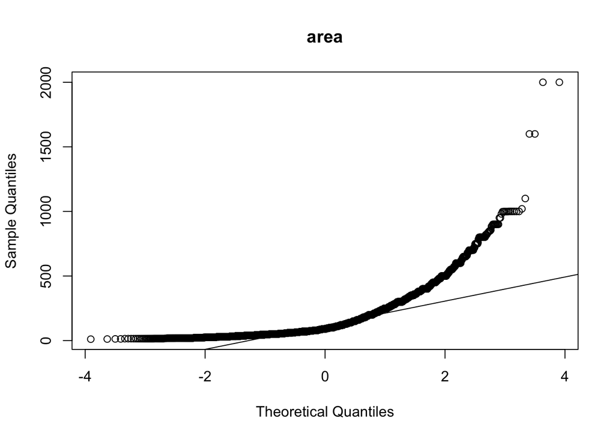

```r
qqnorm(house_data[,"area", drop = TRUE], main = "area")
qqline(house_data[,"area", drop = TRUE])
```

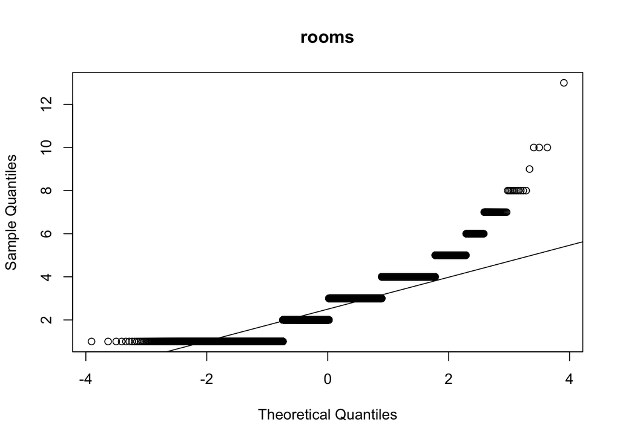

```r
qqnorm(house_data[,"rooms", drop = TRUE], main = "rooms")
qqline(house_data[,"rooms", drop = TRUE])
```

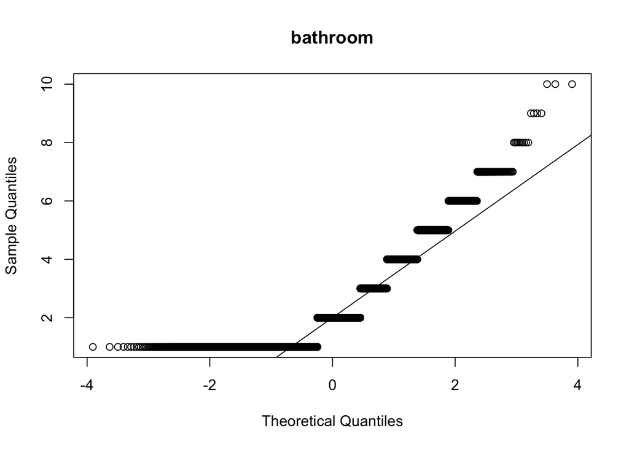

```r
qqnorm(house_data[,"bathroom", drop = TRUE], main = "bathroom")
qqline(house_data[,"bathroom", drop = TRUE])
```

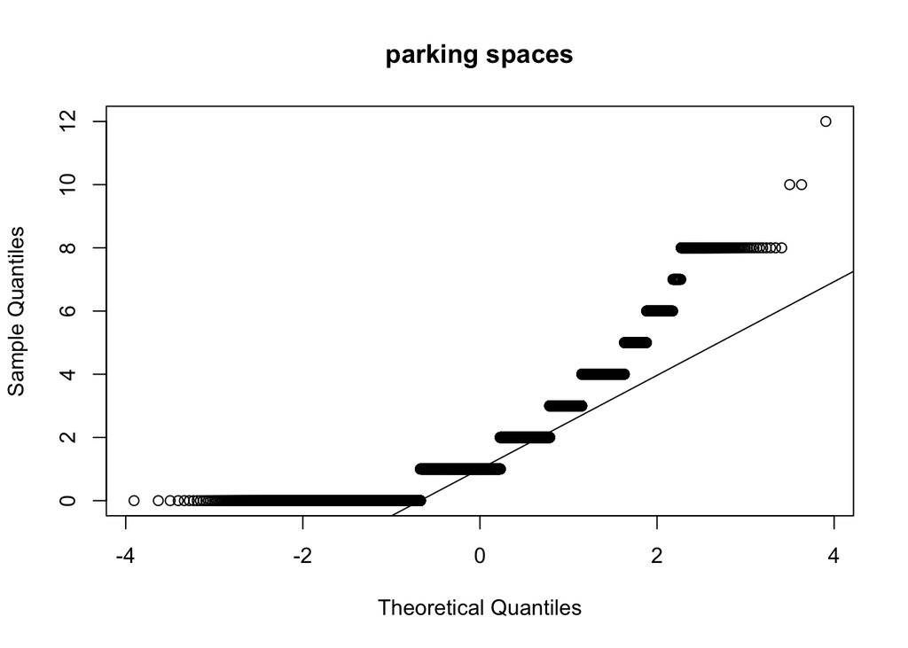

```r
qqnorm(house_data[,"parking spaces", drop = TRUE], main = "parking spaces")
qqline(house_data[,"parking spaces", drop = TRUE])
```

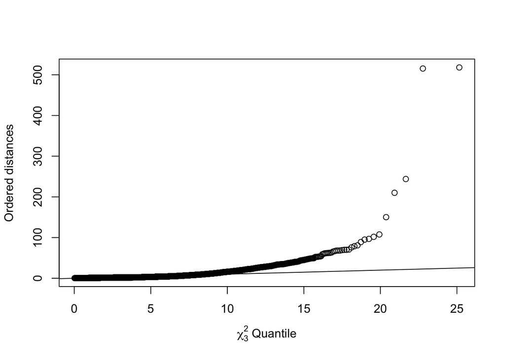

```r
plot(qchisq((1:nrow(x) - 1/2) / nrow(x), df = 4), sort(d),
     xlab = expression(paste(chi[3]^2, " Quantile")),
     ylab = "Ordered distances")
abline(a = 0, b = 1)
```

### In the result, we can find that the data points of these variables appears as a curve and deviates significantly from the qq-line. It shows that the data distribution is significantly different from the standard normal distribution. In the following research, transformation will be used to fit the data into normal distribution.

## Transform the data

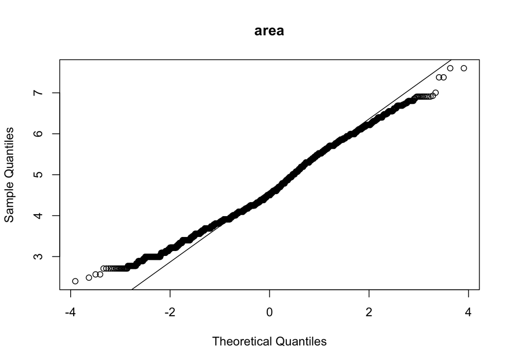

```r
house_data$log_area = log(house_data$area)
house_data$log_rooms = log(house_data$rooms)
house_data$log_bathroom = log(house_data$bathroom)
house_data$log_parking_spaces = log(house_data$"parking spaces" + 1)


qqnorm(house_data[,"log_area", drop = TRUE], main = "area")
qqline(house_data[,"log_area", drop = TRUE])
```

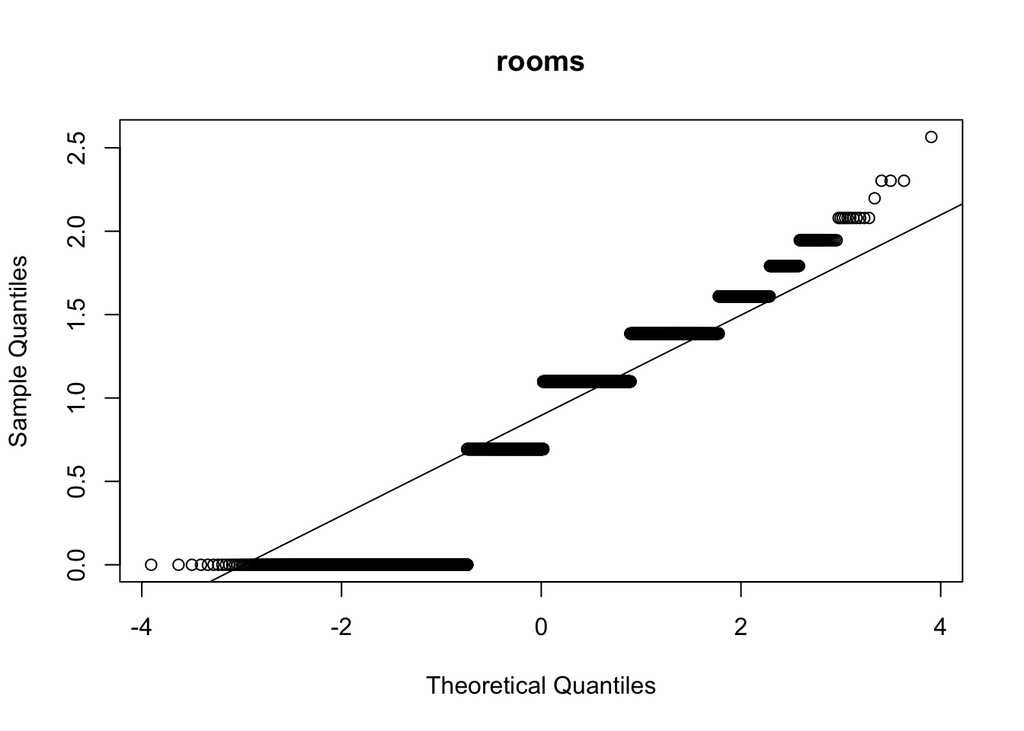

```r
qqnorm(house_data[,"log_rooms", drop = TRUE], main = "rooms")
qqline(house_data[,"log_rooms", drop = TRUE])
```

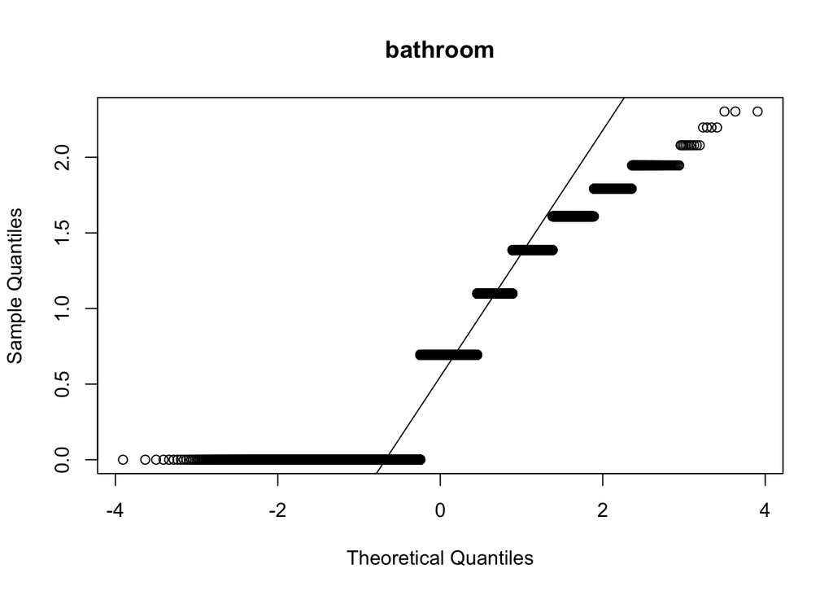

```r
qqnorm(house_data[,"log_bathroom", drop = TRUE], main = "bathroom")
qqline(house_data[,"log_bathroom", drop = TRUE])
```

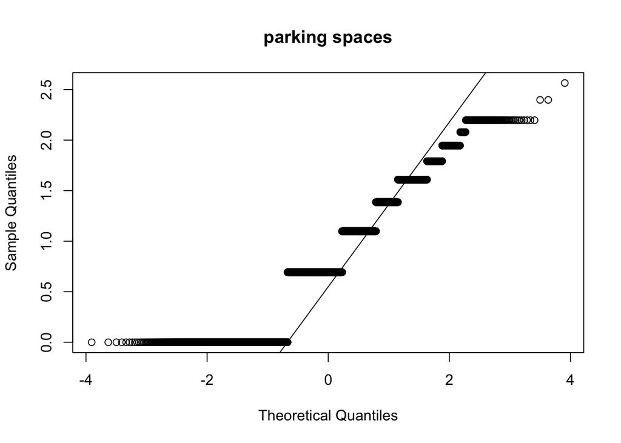

```r
qqnorm(house_data[,"log_parking_spaces", drop = TRUE], main = "parking spaces")
qqline(house_data[,"log_parking_spaces", drop = TRUE])
```

```r
median_amount <- median(house_data$"rent amount", na.rm = TRUE)
house_data$amount_level <- ifelse(house_data$"rent amount" > median_amount, 'high', 'low')
house_data$amount_level <- as.factor(house_data$amount_level)

with(data=house_data,t.test(log_area[amount_level=="high"],log_area[amount_level=="low"],var.equal=TRUE))
```

```
##
##  Two Sample t-test
##
## data:  log_area[amount_level == "high"] and log_area[amount_level == "low"]
## t = 81.094, df = 10675, p-value < 2.2e-16
## alternative hypothesis: true difference in means is not equal to 0
## 95 percent confidence interval:
##  0.961092 1.008705
## sample estimates:
## mean of x mean of y
##  5.110495  4.125596
```

```r
with(data=house_data,t.test(log_rooms[amount_level=="high"],log_rooms[amount_level=="low"],var.equal=TRUE))
```

```
##
##  Two Sample t-test
##
## data:  log_rooms[amount_level == "high"] and log_rooms[amount_level == "low"]
## t = 56.305, df = 10675, p-value < 2.2e-16
## alternative hypothesis: true difference in means is not equal to 0
## 95 percent confidence interval:
##  0.4700906 0.5040025
## sample estimates:
## mean of x mean of y
## 1.0422734 0.5552269
```

```r
with(data=house_data,t.test(log_bathroom[amount_level=="high"],log_bathroom[amount_level=="low"],var.equal=TRUE))
```

```
##
##  Two Sample t-test
##
## data:  log_bathroom[amount_level == "high"] and log_bathroom[amount_level == "low"]
## t = 80.346, df = 10675, p-value < 2.2e-16
## alternative hypothesis: true difference in means is not equal to 0
## 95 percent confidence interval:
##  0.7048707 0.7401241
## sample estimates:
## mean of x mean of y
## 0.9867377 0.2642403
```

```r
with(data=house_data,t.test(log_parking_spaces[amount_level=="high"],log_parking_spaces[amount_level=="low"],var.equal=TRUE))
```

```
##
##  Two Sample t-test
##
## data:  log_parking_spaces[amount_level == "high"] and log_parking_spaces[amount_level == "low"]
## t = 63.155, df = 10675, p-value < 2.2e-16
## alternative hypothesis: true difference in means is not equal to 0
## 95 percent confidence interval:
##  0.5806314 0.6178288
## sample estimates:
## mean of x mean of y
## 1.0922774 0.4930473
```

```r
library(Hotelling)
t2testsparr <- hotelling.test(log_area + log_rooms + log_bathroom + log_parking_spaces ~ amount_level, data=house_data)
# Output of the function hotelling.test is given
cat("T2 statistic =",t2testsparr$stat[[1]],"\n")
```

```
## T2 statistic = 8091.467
```

```r
print(t2testsparr)
```

```
## Test stat:  8091.5
## Numerator df:  4
## Denominator df:  10672
## P-value:  0
```

### According to the result of t-test, we can conclude that there exists significant difference between low value and high value of rent in each variable. Hotelling test also shows that these variables have significant difference between these two groups. As a result, The rent price will be significantly affected by areas, number of rooms, bathrooms, and parkspaces.

## Next, Levene test and Van Valen’s test will be used to check whether the variance in each groups have same variance.

```r
normalized_data <- cbind(scale(house_data[, c("log_area", "log_rooms", "log_bathroom", "log_parking_spaces")], center = FALSE), amount_level = house_data[, "amount_level"])
# levene test
library(car)
leveneTest(log_rooms ~ amount_level, data=house_data)
```

```
## Levene's Test for Homogeneity of Variance (center = median)
##          Df F value    Pr(>F)
## group     1  89.418 < 2.2e-16 ***
##       10675
## ---
## Signif. codes:  0 '***' 0.001 '**' 0.01 '*' 0.05 '.' 0.1 ' ' 1
```

```r
leveneTest(log_area ~ amount_level, data=house_data)
```

```
## Levene's Test for Homogeneity of Variance (center = median)
##          Df F value    Pr(>F)
## group     1  482.05 < 2.2e-16 ***
##       10675
## ---
## Signif. codes:  0 '***' 0.001 '**' 0.01 '*' 0.05 '.' 0.1 ' ' 1
```

```r
leveneTest(log_bathroom ~ amount_level, data=house_data)
```

```
## Levene's Test for Homogeneity of Variance (center = median)
##          Df F value    Pr(>F)
## group     1  478.79 < 2.2e-16 ***
##       10675
## ---
## Signif. codes:  0 '***' 0.001 '**' 0.01 '*' 0.05 '.' 0.1 ' ' 1
```

```r
leveneTest(log_parking_spaces ~ amount_level, data=house_data)
```

```
## Levene's Test for Homogeneity of Variance (center = median)
##          Df F value    Pr(>F)
## group     1  73.971 < 2.2e-16 ***
##       10675
## ---
## Signif. codes:  0 '***' 0.001 '**' 0.01 '*' 0.05 '.' 0.1 ' ' 1
```

```r
#Van Valen's test
d.all <- data.frame(house_data[, "amount_level"],sqrt(rowSums(normalized_data[,-5]^2)))
colnames(d.all)[2] <- "dij"
with(d.all, t.test(dij[amount_level=="low"], dij[amount_level=="low"],var.equal=TRUE, alternative="less"))
```

```
##
##  Two Sample t-test
##
## data:  dij[amount_level == "low"] and dij[amount_level == "low"]
## t = 0, df = 10680, p-value = 0.5
## alternative hypothesis: true difference in means is less than 0
## 95 percent confidence interval:
##        -Inf 0.01576681
## sample estimates:
## mean of x mean of y
##  1.368153  1.368153
```

```r
sprintf("d-values for high prices: Mean = %2.3f, Variance = %2.3f",mean(d.all$dij[d.all$amount_level=="high"]),var(d.all$dij[d.all$amount_level=="high"]))
```

```
## [1] "d-values for high prices: Mean = 2.326, Variance = 0.474"
```

```r
sprintf("d-values for low prices: Mean = %2.3f, Variance = %2.3f",mean(d.all$dij[d.all$amount_level=="low"]),var(d.all$dij[d.all$amount_level=="low"]))
```

```
## [1] "d-values for low prices: Mean = 1.368, Variance = 0.245"
```

## Anova and Manova will be used to test whether there is a significant difference in the means between different groups.

```r
# ANOVA
summary(aov(house_data$log_rooms ~ house_data$amount_level))
```

```
##                            Df Sum Sq Mean Sq F value Pr(>F)
## house_data$amount_level     1  633.2   633.2    3170 <2e-16 ***
## Residuals               10675 2132.1     0.2
## ---
## Signif. codes:  0 '***' 0.001 '**' 0.01 '*' 0.05 '.' 0.1 ' ' 1
```

```r
summary(aov(house_data$log_parking_spaces ~ house_data$amount_level))
```

```
##                            Df Sum Sq Mean Sq F value Pr(>F)
## house_data$amount_level     1  958.5   958.5    3989 <2e-16 ***
## Residuals               10675 2565.2     0.2
## ---
## Signif. codes:  0 '***' 0.001 '**' 0.01 '*' 0.05 '.' 0.1 ' ' 1
```

```r
summary(aov(house_data$log_bathroom ~ house_data$amount_level))
```

```
##                            Df Sum Sq Mean Sq F value Pr(>F)
## house_data$amount_level     1   1393  1393.4    6455 <2e-16 ***
## Residuals               10675   2304     0.2
## ---
## Signif. codes:  0 '***' 0.001 '**' 0.01 '*' 0.05 '.' 0.1 ' ' 1
```

```r
summary(aov(house_data$log_area ~ house_data$amount_level))
```

```
##                            Df Sum Sq Mean Sq F value Pr(>F)
## house_data$amount_level     1   2589  2589.2    6576 <2e-16 ***
## Residuals               10675   4203     0.4
## ---
## Signif. codes:  0 '***' 0.001 '**' 0.01 '*' 0.05 '.' 0.1 ' ' 1
```

```r
# mahalanobis
library(stats)
transformed_x <- house_data[, c("log_area", "log_rooms", "log_bathroom", "log_parking_spaces")]
transformed_cm <- colMeans(transformed_x)
transformed_S <- cov(transformed_x)
transformed_d <- apply(transformed_x, MARGIN = 1, function(transformed_x)t(transformed_x - transformed_cm) %*% solve(transformed_S) %*% (transformed_x - transformed_cm))
transformed_MD <- mahalanobis(transformed_x, transformed_cm, transformed_S)
head(transformed_MD)
```

```
## [1]  9.580076  4.140969  8.220833 13.176031  2.476770 18.494459
```

```r
house_data$pvalues <- pchisq(transformed_MD, df=3, lower.tail=FALSE)


# BoxM

library(biotools)
boxM(house_data[,11:14],house_data$amount_level)
```

```
##
##  Box's M-test for Homogeneity of Covariance Matrices
##
## data:  house_data[, 11:14]
## Chi-Sq (approx.) = 1220.6, df = 10, p-value < 2.2e-16
```

```r
# MANOVA
summary(manova(as.matrix(house_data[,11:14])~ house_data$amount_level))
```

```
##                            Df  Pillai approx F num Df den Df    Pr(>F)
## house_data$amount_level     1 0.43117   2022.3      4  10672 < 2.2e-16 ***
## Residuals               10675
## ---
## Signif. codes:  0 '***' 0.001 '**' 0.01 '*' 0.05 '.' 0.1 ' ' 1
```

### According to the result of the Anova and Manova, the rent amount level significantly influence multiple variables.